# Comparing drug target libraries using enrichment analysis

Damon Pham

## Project description

I measured agreement using enrichment analysis–specifically, the Fisher’s exact test for overrepresentation. I treated each (drug, expanded target list) from the drug target libraries as an (annotation, gene set) pair, and each (drug sample, list of most-perturbed genes) from the drug perturbation signature libraries also as an (annotation, gene set) pair. I then performed enrichment into one library using the gene sets from the other library, and observed how highly the matching annotations, i.e. those which correspond to the same drug as the input, were ranked. If two libraries agree with one another, then these matching annotations should often be highly ranked.

## Setup

In order to perform enrichment analysis, I needed to do three things:

1. Convert all libraries to gene vector matrix (gvm) format. In this format, each drug annotation is a column label, and each gene, represented by its HGNC symbol, is a row label. Cell values are TRUE or FALSE depending on whether the column annotation is associated with the row gene. For completeness, I also obtained gmt files for each of the libraries.
2. Identify matching annotations, i.e. drug synonyms, among the libraries. I accomplished this by renaming each annotation to its corresponding drug’s PubChem Compound ID. This was done by using the webchem R package to query PubChem’s synonym database with the drug name(s) or different database ID(s) for each annotation. If I could not obtain a PubChem Compound ID, I instead used the drug’s common name, with alphanumeric characters only, and all letters in lowercase.
3. Expand the gene sets of the drug target libraries. Each drug only targets a few genes directly, but through gene-gene interactions they often indirectly regulate the expression of many more genes. I tried to capture the net effect of each drug by adding to its gene set the 100 most interacting or co-expressed genes, for each gene in the original set.

These steps are described below. I first complete steps (1) and (2) for each library. Then, I summarize their properties and complete step (3) before performing enrichment analysis.

#### DrugBank, TCRD, DrugRepHub, DGIdb, and DrugCentral

For each drug, these five drug target libraries have a name and ChEMBL ID (always present), as well as a DrugBank ID and SMILES (sometimes missing). I began by aggregating all drugs across these libraries. Then, I tried to obtain the PubChem IDs by using, in this order:

- the ChEMBL ID
- the Drug Name
- the DrugBank ID, if any
- the SMILES, if any
- the cleaned Drug Name (alphanumeric characters only)

I was unable to obtain PCIDs for 82 out of 1820 annotations.

Next, for each library, I checked for compounds which have different ChEMBL IDs but were assigned the same PubChem ID.

This issue only occured in the Drug-Gene Interaction database. Here, Su-014813 is identical to su-14813. Pergolide is administered as a mesylate salt. Me-344 is a metabolite of nv-128. Enoxaparin and heparin are similar: enoxaparin is often called “low-molecular-weight heparin.” I decided to allow these compounds to be equated.

Now that I obtained the PubChem IDs, I transformed the libraries into gene vector matrices and used the PubChem IDs (or the drug’s common name if the PubChem ID was not found) as the column annotation names.

#### STITCH

The chemical names are given as PubChem CIDs, so I kept them as is.

The proteins are given as ENSP IDs, so I converted as many as possible to HGNC format using the biomaRt R package.

197 out of 18070 ENSP IDs were unable to be converted.

Drug-protein interactions are given a Confidence Score from 150 to 1000, with higher numbers indicating higher probability of intereaction. Here is a table summarizing the drug sets in STITCH after applying different cutoffs for interaction Confidence Scores.

Table 1: Summary statistics for STITCH interactions with different combined score cutoffs

| Combined Score cutoff | Number of unique chemicals | Average number of protein interactions per chemical |
| --- | --- | --- |
| 300 | 322411 | 10.92 |
| 400 | 264029 | 5.80 |
| 500 | 207799 | 4.66 |
| 600 | 148303 | 4.57 |
| 700 | 91282 | 4.80 |
| 800 | 40113 | 5.95 |
| 900 | 16619 | 4.92 |

I decided to make gmts and gvms for cutoff levels 500, 600, 700 and 800. To be consistent with the five previous libraries, I only kept chemicals with at least five interactions afer applying the cutoff. I also made gmts and gvms with proteins whose ENSP ID could not be converted to a HGNC name removed. These are what I will use for enrichment analysis.

#### Drug Target Commons

This library has many interactions. I filtered on the following columns:

- `wildtype_or_mutant`: removing interactions for mutated cell lines.
- `activity_comments`: only keeping interactions with comments that confirmed activity, or which I was unsure how to interpret. This means I removed interactions with negative or inconclusive activity, or which were blank.

This library is actually a protein-drug interaction database, so I also converted the UniProt protein IDs to HGNC symbols using the UniProt.ws R package. I removed interactions for which the protein ID could not be converted.

Next, I tried to obtain the PubChem IDs by using, in this order:

- the ChEMBL ID
- the Standard InChIKey
- the compound name
- the cleaned compound name (alphanumeric characters only)

For the final gvm name I used the PCID, or the drug name if that was unavailable, or the ChEMBL ID if both were unavailable.

#### CREEDS and the LINCS 1000

Each drug perturbation signature library was originally two separate gmt files: one for the up-perturbed genes, and one for the down-perturbed genes. I first merged these files by taking the union of up-perturbed and down-perturbed genes for each sample. I then converted this to a gene vector matrix with each sample as its own column.

The next step was to obtain the PubChem IDs.

*CREEDS*: In CREEDS, the annotation of each sample contains both a name and a DrugBank ID. In addition, some names have a synonym in parentheses. I began by extracting and scrubbing the drug name and DrugBank ID. I then removed embedded synonyms from the drug name.

I tried to obtain the PubChem IDs by using the following information, in this order:

- the Drug Name
- the DrugBank ID
- the synonym, if any
- the cleaned Drug Name
- the cleaned synonym, if any

Out of 263 unique drugs, I was unable to obtain 28 PCIDs. I used the drug name if the PCID could not be found.

*LINCS*: I extracted the drug names from the sample annotations. I then removed embedded synonyms.

I tried to obtain the PubChem IDs by using the following information, in this order:

- the Drug Name
- the synonym, if any
- the cleaned Drug Name
- the cleaned synonym, if any

I was unable to obtain PCIDs for 411 out of 3907 annotations. I used the drug name if the PCID could not be found.

#### Comparison of libraries

*Summary statistics*: Here is a table summarizing the features of each drug library.

Table 2: Summary of all drug libraries

| Name | Library Type | Description | Samples | Unique drugs | Targets | Average targets per annotation | Data preprocessing |
| --- | --- | --- | --- | --- | --- | --- | --- |
| [DrugBank](http://drugbank.ca) | Drug Target | Encyclopedia-like drug database compiled from scientific publications. | NA | 440 | 1468 | 11.98 | Edgelist. Removed samples missing the ChEMBL_ID, or with less than five targets. |
| [Target Central Resource Database](http://juniper.health.unm.edu/tcrd) | Drug Target | Part of the “Illuminating the Druggable Genome” project, which compiles data from multiple sources and emphasizes GPCR, kinase, ion channel and nuclear receptor targets. | NA | 136 | 518 | 10.42 | Edgelist. Removed samples missing the ChEMBL_ID, or with less than five targets. |
| [Drug Gene Interaction Database](http://dgidb.org) | Drug Target | Drug-gene interactions compiled by curation and text-mining from multiple sources. | NA | 1207 | 2087 | 11.76 | Edgelist. Removed samples missing the ChEMBL_ID, or with less than five targets. |
| [Drug Repurposing Hub](http://clue.io/repurposing) | Drug Target | Drug screening library containing known clinical drugs and their targets as reported by scientific publications. | NA | 614 | 1581 | 10.64 | Edgelist. Removed samples missing the ChEMBL_ID, or with less than five targets. |
| [Drug Central](http://drugcentral.org) | Drug Target | Database of drugs approved or regulated by government agencies. | NA | 711 | 1329 | 14.99 | Edgelist. Removed samples missing the ChEMBL_ID, or with less than five targets. |
| [Drug Target Commons](http://drugtargetcommons.fimm.fi) | Drug Target | Drug bioactivity database extracted and organized from multiple sources by crowdsource. | NA | 19033 | 1114 | 9.02 | Converted UniProt protein IDs to HGNC symbols. Removed samples with blank, negative, and inconclusive activities, mutant cell lines, missing an HGNC symbol, or with less than five targets. |
| [Search Tool for Interacting Chemicals (STITCH), 500 cutoff](http://STITCH.embl.de) | Drug Target | Chemical-protein interaction network obtained from computational predictions, inter-organism knowledge, and other databases. | NA | 13272 | 12479 | 24.94 | Converted ENSP IDs to HGNC symbols. Used an interaction score cutoff of 500. Removed samples with less than five targets. |
| [STITCH, 600 cutoff](http://STITCH.embl.de) | Drug Target | See above. | NA | 7985 | 11470 | 30.53 | Interaction score cutoff of 600 |
| [STITCH, 700 cutoff](http://STITCH.embl.de) | Drug Target | See above. | NA | 5494 | 10490 | 34.90 | Interaction score cutoff of 700 |
| [STITCH, 800 cutoff](http://STITCH.embl.de) | Drug Target | See above. | NA | 4021 | 8311 | 36.53 | Interaction score cutoff of 800 |
| [CRowd Extracted Expression of Differential Signatures](http://amp.pharm.mssm.edu/CREEDS) | Perturbation Signature | Human, mouse and rat drug perturbation signatures extracted from the Gene Expression Omnibus by crowdsource. | 906 | 263 | 17999 | 366.79 | Took the union of up and down DE gene sets from Enrichr gmts. |
| [Library of Integrated Network-Based Cellular Signatures](http://lincsproject.org) | Perturbation Signature | Gene expression profiles from flow cytometry experiments with different perturbagens, time points, doses, and cell lines. | 33132 | 1531 | 10330 | 135.89 | Took the union of up and down DE gene sets from Enrichr gmts. |

*Comparison of drug sets*: Each library measures different populations of drugs. I first looked at the size of the intersection between each drug target library with each drug perturbation library, to see if my enrichment analysis benchmarking method would be feasible.

In addition to looking at these pairwise intersection sizes, I also looked at the overall similarities of each library using a heatmap with hierarchical clustering.

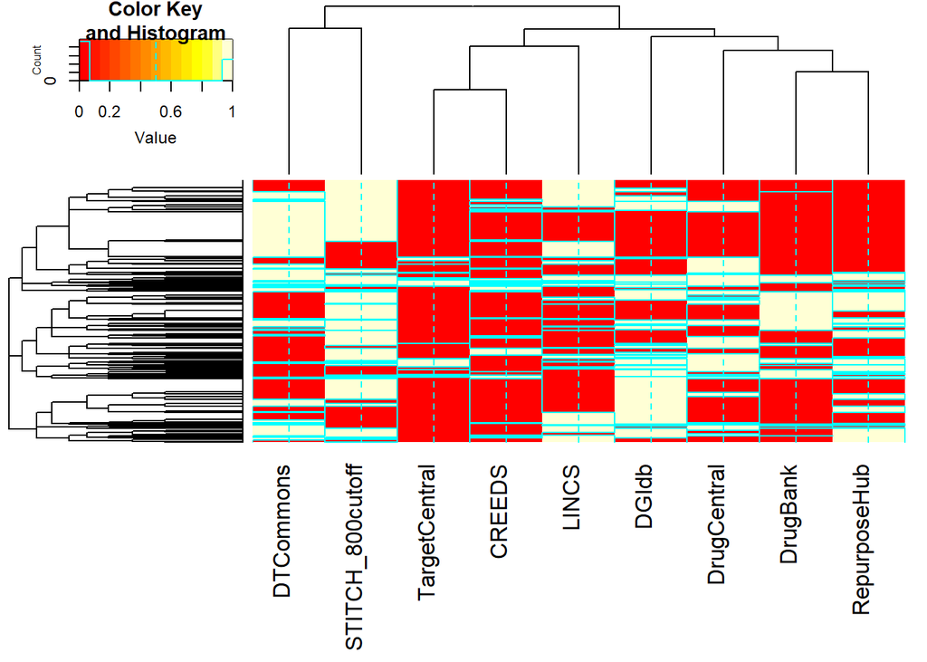

Figure 1: Heatmap and hierarchical clustering of drug libraries

STITCH and Drug Target Commons, the largest two libraries, share many drugs which are not represented in the other libaries. TargetCentral, CREEDS and LINCS seem to be similar to each other, with DGIdb, DrugCentral, DrugBank and RepurposeHub forming the other cluster.

Finally, I used the UpSet R package to visualize the frequency of set memberships between the libraries. Here are the top 40 set memberships:

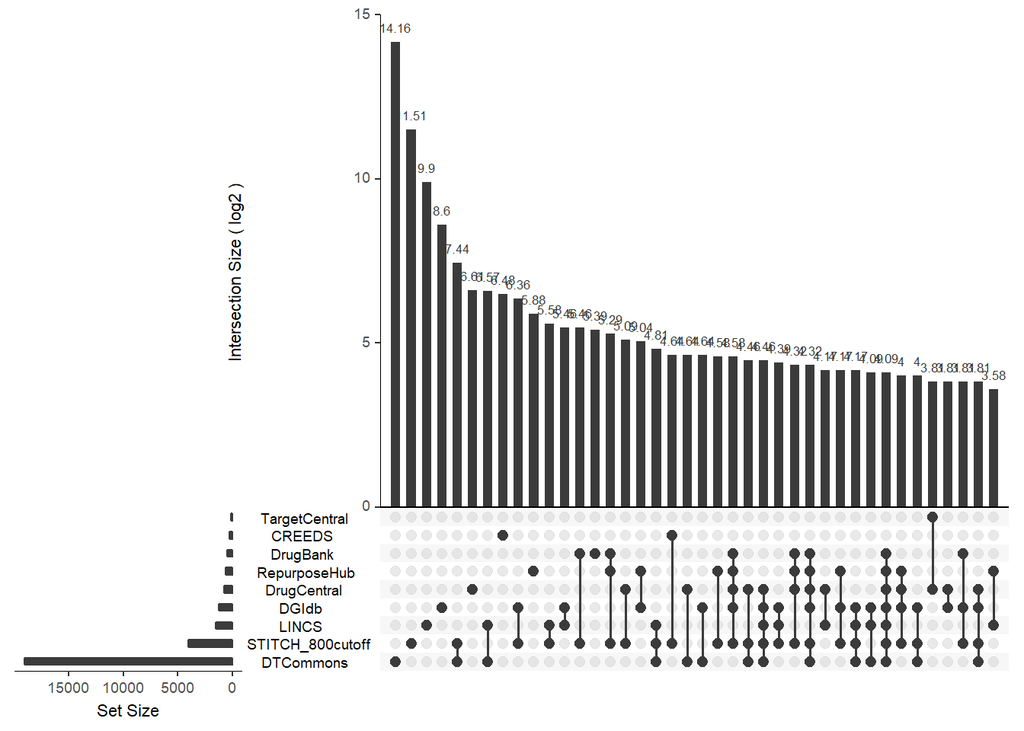

Figure 2: Largest intersection sets between the drug libraries

It is most common for drugs to be included in only one of the larger libraries. For drugs that belong to multiple libraries, one of the libraries they belong to is often either STITCH or DTCommons. TargetCentral, and CREEDS to a lesser extent, is not well represented within the largest intersection sets.

#### Expansion with coexpression or PPI data

The average gene set sizes for the drug target libraries (DrugBank, TargetCentral, DGIdb, DrugRepHub, DrugCentral, DTCommons, and STITCH) are too small for enrichment analysis. These libraries were expanded using data from three sources: ARCHS4 (a gene coexpression database), hu.MAP, and BioGRID (both PPI databases).

To do this, coexpression/interaction sets were extracted from each library by taking the top 100 coexpressed/interacting genes/proteins for each gene/protein. (For BioGRID, since interaction scores are not provided, the first 100 entries for each protein, from top to bottom in the original file, were kept.) Then, each gene set in the drug libraries is expanded by adding to it the coexpression/interaction set of each gene in the original set. For example, the gene set {CTPS, MLLT11} becomes the union of: (1) {CTPS, MLLT11}, (2) the coexpression/interaction set for CTPS, and (3) the coexpression/interaction set for MLLT11. (If a gene does not appear in the expansion library, the coexpression/intereaction set is interpreted as just the gene itself.) The result is three new drug target libraries for each original drug target library: one for each expansion library.

## Enrichment analysis

After creating the expanded libraries, I performed enrichment analysis, using the Fisher’s exact test, between each drug target library and perturbation signature library pair.

See https://github.com/MaayanLab/Enrichment_Sandbox for an explanation of how enrichment analysis is used to measure the agreement between different gene set libraries, and how to interpret the bridge plots.

Here are the results I obtained so far:

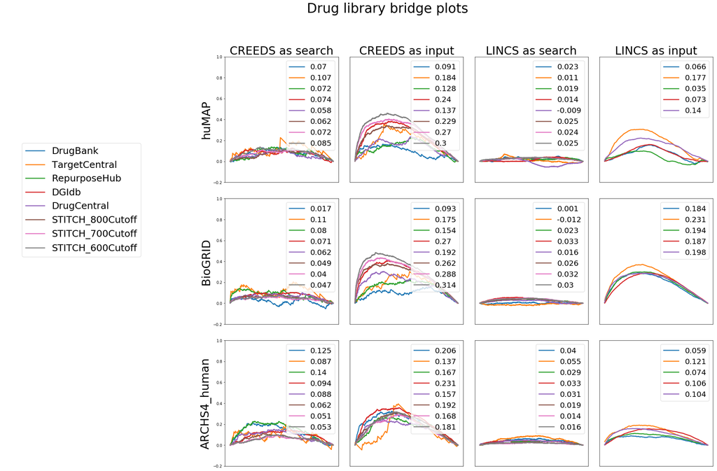

Figure 3: Enrichment analysis results